# Projeto 1: Análise Exploratória de Dados

Marjorie Hoegen

Por meio de uma análise exploratória é possível identificar erros e inconsistências em bancos de dados, visualizar padrões e correlações e começar a desenvolver hipóteses. O objetivo deste primeiro projeto é realizar uma análise exploratória do dataset **storms** (biblioteca dplyr) que descreve 198 tempestades tropicais com medições de seus atributos a cada 6 horas. No total, são 10,010 observações e 13 variáveis.

### Visualização inicial

Para conhecer melhor os dados, é importante uma visualização inicial.

Na tabela abaixo podemos ver as 13 colunas deste banco de dados.

| name | year | month | day | hour | lat | long | status | category | wind | pressure | ts_diameter | hu_diameter |
| --- | --- | --- | --- | --- | --- | --- | --- | --- | --- | --- | --- | --- |
| Amy | 1975 | 6 | 27 | 0 | 27.5 | -79.0 | tropical depression | -1 | 25 | 1013 | NA | NA |
| Amy | 1975 | 6 | 27 | 6 | 28.5 | -79.0 | tropical depression | -1 | 25 | 1013 | NA | NA |
| Amy | 1975 | 6 | 27 | 12 | 29.5 | -79.0 | tropical depression | -1 | 25 | 1013 | NA | NA |
| Amy | 1975 | 6 | 27 | 18 | 30.5 | -79.0 | tropical depression | -1 | 25 | 1013 | NA | NA |
| Amy | 1975 | 6 | 28 | 0 | 31.5 | -78.8 | tropical depression | -1 | 25 | 1012 | NA | NA |
| Amy | 1975 | 6 | 28 | 6 | 32.4 | -78.7 | tropical depression | -1 | 25 | 1012 | NA | NA |

As únicas duas colunas que não são auto explicativas são as duas últimas: ts_diameter e hu_diameter. Na descrição o dataset é definido que:

- ts_diameter é o diâmetro da área onde ocorreram ventos com a força de uma tempestade tropical (de 34 nós para cima)
- hu_diameter é o diâmetro da área onde ocorreram ventos com a força de um furacão (de 64 nós para cima)

E já é possível ver que não possui vários valores (N/A), o que deve ser levado em conta caso seja feita alguma análise come essas variáveis.

### Algumas informações a mais usando summary()

Para obter algumas informações adicionais podemos visualizar a média, e os mínimos e máximos de algumas variáveis, por exemplo. Assim, é possível ver que esse dataset tem informações das tempestades desde 1975 até 2015.

```r
summary(data %>% select(year, lat, long, status, category, wind, pressure))
```

```
##       year           lat             long            status
##  Min.   :1975   Min.   : 7.20   Min.   :-109.30   Length:10010
##  1st Qu.:1990   1st Qu.:17.50   1st Qu.: -80.70   Class :character
##  Median :1999   Median :24.40   Median : -64.50   Mode  :character
##  Mean   :1998   Mean   :24.76   Mean   : -64.23
##  3rd Qu.:2006   3rd Qu.:31.30   3rd Qu.: -48.60
##  Max.   :2015   Max.   :51.90   Max.   :  -6.00
##
##  category       wind           pressure
##  -1:2545   Min.   : 10.00   Min.   : 882.0
##  0 :4373   1st Qu.: 30.00   1st Qu.: 985.0
##  1 :1685   Median : 45.00   Median : 999.0
##  2 : 628   Mean   : 53.49   Mean   : 992.1
##  3 : 363   3rd Qu.: 65.00   3rd Qu.:1006.0
##  4 : 348   Max.   :160.00   Max.   :1022.0
##  5 :  68
```

Podemos agrupar as tempestades classificadas como furacão para saber quantos furacões diferentes foram registrados durante esse período de tempo.

```r
hurricanes <- filter(data, status == "hurricane")
n_hurricanes <- hurricanes %>% group_by(year) %>% summarise(count = n_distinct(name))
head(n_hurricanes)
```

```
## # A tibble: 6 x 2
##    year count
##   <dbl> <int>
## 1 1975.     2
## 2 1976.     2
## 3 1977.     3
## 4 1978.     1
## 5 1979.     5
## 6 1980.     6
```

### Visualização por gráficos

Um gráfico simples de ser feito é um que relacione o número de tempestades distintas por ano. Como os registros foram feitos a cada 6 horas primeiramente é necessário agrupar os nomes repetidos contando os nomes distintos.

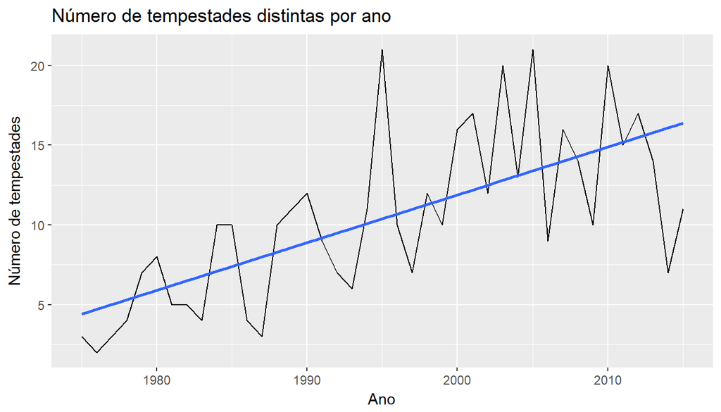

```r
by_year <- data %>% group_by(year) %>% summarise(count = n_distinct(name))
g1 <- ggplot(by_year, aes(x=year, y=count)) +
    geom_line() +
    geom_smooth(method='lm', se = FALSE) +
    labs(title = "Número de tempestades distintas por ano", x = "Ano", y = "Número de tempestades")
 g1
```

Pode-se notar que, de maneira geral, o número de tempestades tem aumentado ao longo dos anos. Porém, deve-se levar em conta a maneira como o banco de dados foi construído. Uma causa para esse aumento pode ser o fato de mais tipos de tempestades terem sido registrados do que no início. Essa relação do aumento com o tempo deveria ser estudada mais a fundo antes de podermos tirar conclusões.

Também podemos descobrir quais são os nomes mais utilizados para tempestades e visualizar graficamente.

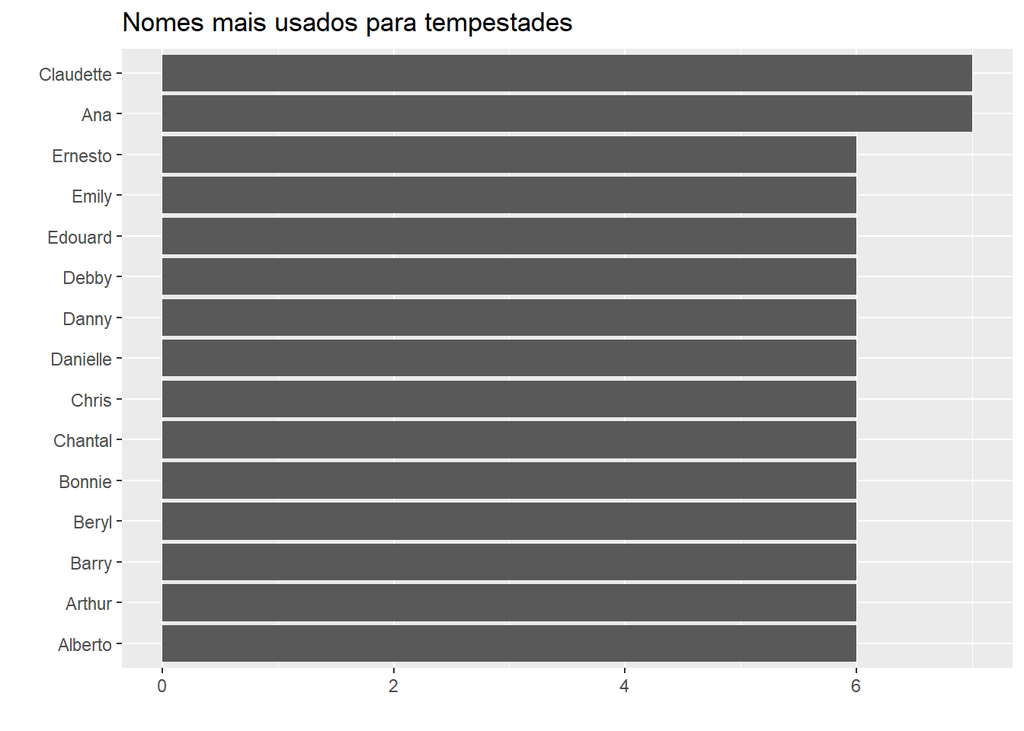

### Conclusão

Com essa análise inicial básica já foi possível identificar alguns dados e começar a explorar para poder levantar e testar hipóteses. Foi possível ver como a utilização do R facilita o trabalho quando é necessário lidar com uma grande quantidade de dados e variáveis.